# Introductory data science (ongoing)

Author

Maria Teresa Mendes Madureira

# poverty, data transfers gender inequality- an analysis of time distribution inside families of Mexico

Introduction to Progresa and the database.

Some necessary information about the main variables.

Cleaning the dataset and uploading libraries

Variable dictionary

Understanding family income

Understanding time distribution

Next steps

## Introduction to Progresa and the database.

Mexico is similar to Brazil in many ways. Both countries face similar challenges in poverty, gender inequality and integrating families from isolated regions into the national economic network. They also have a similar solution to some of these problems- conditional cash transfer programs. Mexico has a very close equivalent to our “Bolsa Família”, which was originally called “Progresa”. Although “Progresa” is its original name, the program went through many rebrandings through the years, and is also known as “Oportunidades” and “Prospera”. Currently, what we understand as Progresa functions under the many programs coordenated by the Secretaria de Bienestar.

Progresa, like Bolsa Familia, is a conditional cash transfer, and requires minors to be enrolled in school, make yearly visits to the doctor and be fully vaccinated. However, its target audience is slightly different from Bolsa Familia’s. Progresa targets families in isolated areas, and so in addition to individual poverty participants must also belong to marginalized regions. The way cities and villages are categorized is not fully disclosed to the public, but it is known it is a mixture of access to basic infrastructure, average income percapita and expenditure on different goods.

Here, I will explore variables affecting time and income distribution, and analyse the impact that progresa had on poorer families. I will focus on women and underage girls.

### Accessing the database

The datasets used to be available in the progresa website, before the program went through an agressive rebranding. I will use data from 2008. At that point, the program had been active for 18 years. Currently, social programs including what we understand as progresa can be found under “Bienestar”.

I use five datasets-

1. Hogares- information on basic infrastructure and household
2. Poplación- information on the individual
3. Ingreso- information on sources of income
4. Concentrado- general information
5. trabajo- information on jobs and work-related income

#### technical information:

#### [Bienestar website](https://www.gob.mx/becasbenitojuarez)

r version- R 4.5.1

reference year- 2008

## Some necessary information about the main variables.

### Conapo

Conapo is the way policy-makers classify towns and villages. It is a technical classification, so the alterations I make for it to become more intuitive do not harm the comprehension of my observations in any way. Conapo ranges from Highly Marginalized town (1) to Not marginalized (5).

Marginalization is a combination of different variables, amongst them avg expenditure, access to different forms of infrastructure, and income. The exact calculation does not seem to be publically available. Conapo already takes into account geographic discrimination, so what I classify here as larger towns are not below 3 in the Conapo scale.

### Progresa

Although I compared progresa to bolsa familia, they have one relevant difference- progresa was born as a rural-focused program, so the data transfer is available only to people from Conapo<3 towns. Aditionally, the income per capita of family members needs to be below 900 mexican pesos.

The program’s requirements aside from income/region are similar to bolsa familia’s- children must be in school, vaccinated and go on yearly visits to the doctors. To account for gender inequality and combat the issue of women leaving school earlier than men, progresa transfers a larger amount to families with daughters enrolled in school.

### Time expenditure

Follows the categories of time distribution I use here. These will be measured in minutes and are available for anyone above 8 years old:

- Fetching water
- care taking
- household chores
- free time
- maintenance

### Household expenditure distribution

Here, I will work with the percentage of each good in relation to the total household consumption. I focus on the following categories:

- food
- clothes
- education
- transportation
- personal

## Cleaning the dataset and uploading libraries

Before any analysis, I load all the libraries and datasets, and transform the variables into the formats described above.

Here I import and clean any and all necessary dataframes, merging them into a single df which will be the only one used throughout the project.

## Variable dictionary

Variable dictionary

| Variável | Tipo | Descrição |
| --- | --- | --- |
| folioviv | character | a 6 digit code unique to each household. |
| lar | character | - |
| numren | character | ennumerates household members |
| sexo | factor | individual's gender |
| parentesco | character | individual's relation to house chief |
| edad | integer | individual's age |
| asis_esc | factor | whether individual is enrolled in school |
| ganha_bolsa | integer | whether the individual has a scholarship |
| redsoc_1 | numeric | on a scale of 1-6, how much help could this individual get on a medical emergency |
| redsoc_3 | numeric | ---- family emergency |
| redsoc_6 | numeric | ---- another emergency |
| trabajo | integer | whether the individual works |
| htrab | integer | how many hours the individual works |
| conapo | numeric | the conapo category of the individual's town |
| ing_tri | numeric | total family progresa transfers. Appears only in the mother's collumn. |
| progresa | character | whether the individual receives progresa transfers |
| renda_tot | numeric | total family income |
| estrato | character | size of individual's town |
| tam_hog | integer | number of individuals in the household |
| tot_hom | integer | number of men in the household |
| tot_muj | integer | number of women in the household |
| valor_bolsa | numeric | individual's scholarship, if they receive it |
| bene_gob | numeric | same as ing_tri, but distributed among all family recipients |
| tempo_cuida | numeric | minutes per week spent on caretaking |
| tempo_repara | numeric | minutes per week spent on maintenance |
| tempo_domestico | numeric | minutes per week spent on housework |
| tempo_agua | numeric | minutes per week spent fetching water |
| tempo_prazer | numeric | free time in minutes per week |
| porcent_vest | numeric | % of income spent on clothing |
| porcent_edu | numeric | % of income spent on education |
| porcent_sld | numeric | % of income spent on health |
| porcent_trans | numeric | % of income spent on transportation |
| porcent_pers | numeric | % of income spent on personal expenses |
| porcent_ali | numeric | % of income spent on food |
| porcent_viv | numeric | percent of income spent on house maintenance |
| porcent_limp | numeric | percent of income spent on cleaning |
| porcent_man | numeric | percent spent on other |
| sex_sit_final | character | if family chief married, single man or single woman |
| ingr_tri | numeric | used to create another variable |
| family_size | integer | used to create another variable |
| ing_percap | numeric | income percapita |
| marital_status | character | Marital status |

## Understanding family income

Many things can affect the way a family chooses to distribute its resources- from the bargaining power of each member, to their income. The aim of this section is to observe how different factors influence family income, so that later we can relate these factors to different ways these families may choose to distribute said income. In order for me to better understand what is behind income, I run a multiple regression.

Since this regression is under family income and not salary, gender (for example) does not seem to have a statistically significant impact. What does have significant impact is the interaction between marital status and gender. What this impact shows us, is that, among single income families, families with a single mother have in fact lower income than families with a single father. Evidently, double-income families tend to earn more than any and all configurations of single-income families.

```
Regression on familial income. NOT SALARY
============================================================
                                    Dependent variable:
                                ----------------------------
                                       log(renda_tot)
------------------------------------------------------------
edad                                      0.007***
                                          (0.0002)

sexoMenina                                 0.010
                                          (0.006)

marital_statussingle                     -0.178***
                                          (0.023)

conapo                                    0.205***
                                          (0.002)

porcent_ali                              -1.630***
                                          (0.011)

sexoMenina:marital_statussingle          -0.070***
                                          (0.025)

Constant                                  9.584***
                                          (0.016)

------------------------------------------------------------
Observations                               44,214
R2                                         0.480
Adjusted R2                                0.480
Residual Std. Error                  0.616 (df = 44207)
F Statistic                     6,810.693*** (df = 6; 44207)
============================================================
Note:                            *p<0.1; **p<0.05; ***p<0.01
```

Although this project is not focused on expenditure distribution, but rather on time distribution, understanding what characteristics impact income negatively can help characterize the demographic of Progresa recipients, and understand who is more susceptible to income vulnerability and therefore targeted by Progresa to receive the cash transfers.

## Understanding time distribution

The way a person chooses to spend their time says much about the commodities they have access to, the challenges they face and the impact of the public policies that target them. A further look into underage girls time distribution compared to boys’ would shine some much needed light on the origin of gender inequalities, especially when it comes to how each gender spends their time at home. After all, it is not only after marriage that girls start contributing more to housework- that pattern has been formed by chidhood behavior and by observing how parents distribute chores. Therefore, it is important to know at what point gender starts making a difference.

### a general view

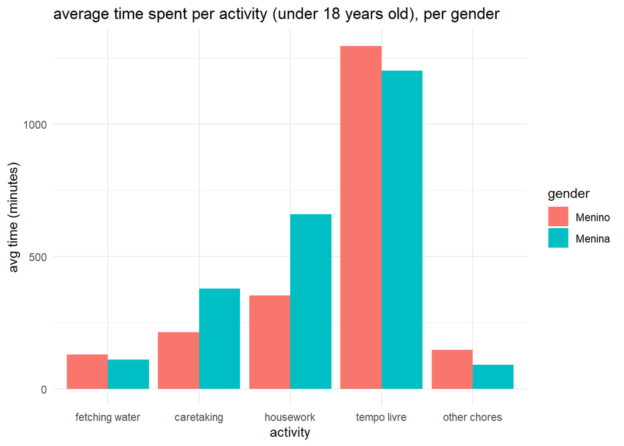

Female-centered activities (caretaking and housework) present a gender gap, while both men and women spend little time on male-dominated activities. Therefore, men have slightly more free time than women.

This graph is limited to underage boys and girls, but in future versions of this project it would be desirable to allow the viewer to choose which age group they would like to observe.

### Linear regression on Time spent on housework

To better understand what is behind the housework gap, a linear regression can help us.

```
Regression on time spent on housework, for population under 20
=================================================================
                                         Dependent variable:
                                    -----------------------------
                                           tempo_domestico
-----------------------------------------------------------------
asis_escNão                                  -64.616***
                                              (14.057)

sexoMenina                                   267.990***
                                              (14.725)

ing_percap                                    -0.003***
                                              (0.0003)

edad                                          3.026***
                                               (0.295)

conapo                                         -2.713
                                               (2.554)

tot_muj                                       -6.835***
                                               (2.489)

parentescofilho(a)                           -119.343***
                                              (35.319)

parentescopartner                            204.140***
                                              (19.482)

marital_statusnot_single                     -227.299***
                                              (33.435)

marital_statussingle


asis_escNão:sexoMenina                       327.009***
                                              (19.394)

sexoMenina:marital_statusnot_single          480.473***
                                              (23.678)

sexoMenina:marital_statussingle               96.416**
                                              (37.433)

Constant                                     470.563***
                                              (39.574)

-----------------------------------------------------------------
Observations                                   70,015
R2                                              0.270
Adjusted R2                                     0.270
Residual Std. Error                     852.648 (df = 70002)
F Statistic                         2,153.565*** (df = 12; 70002)
=================================================================
Note:                                 *p<0.1; **p<0.05; ***p<0.01
```

Here, we confirm what was previously suspected- that the main factor behind time spent doing housework is gender. However, not going to school whilst being a girl also plays an important part. In mexico, young girls tend to leave school earlier than boys because gender biases make female education seem futile. Progresa combats this issue by giving larger cash transfers to families who keep daughters in school.

This calls into question how efficient Progresa is at altering time distributions.

### Progresa’s impact on time distribution

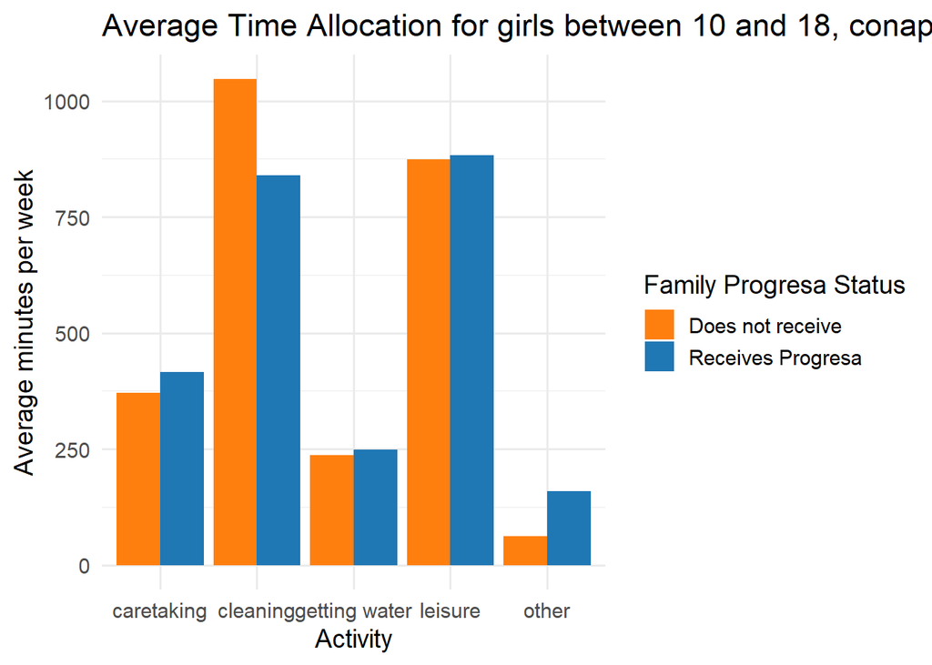

The bigger difference for underage girls seems to be the time spent on housework. However, mothers are also affected by progresa’s focus on young girls. With the compulsory school attendance, women likely have more time to work outside of their home. They might, however, have to make up for the help their daughters have now stopped giving.

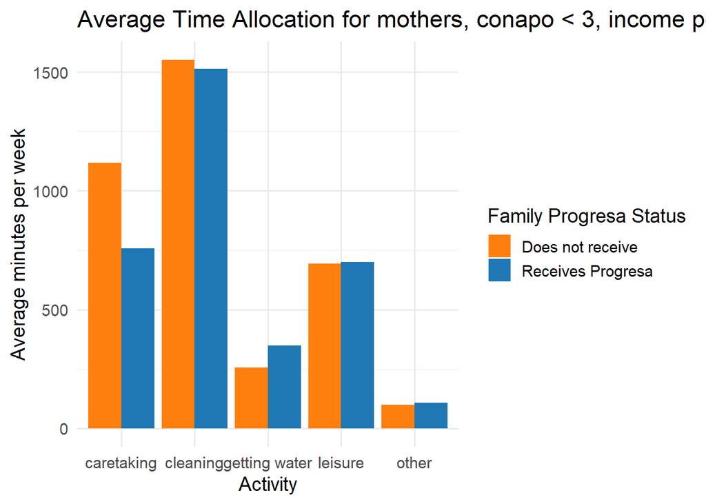

It is important to note that here, there is no differentiation between married or single women, since in the next steps I plan on allowing the viewer to select which group they want to view a chart on.

Progresa’s conditional cash transfer is able to change time distribution for all ages. Young girls do less housework, presumably because they have compulsory attendance rates in school, and are not allowed to abandon their education. Mothers, in turn, spend less time on caretaking, since their children (of all ages) are going to school. As we can see, their leisure time does not change, presumably because they are taking up other obligations during that free time.

## Next steps

More complex and interactive graphs where the reader is able to select which information they may want to access, and in which format. (Our World in Data style).

When it comes to the linear regression specifically, I would like for anyone accessing the project to do the following:

1. given an “explained” variable, like time spent on housework, the user should be able to pick from a list of explanatory variables and be given visual insights into how the explanatory variable affects the explained variable.
2. given a level variable, the user should be able to filter the levels included in the analysis
3. given a continuous variable, the user should be able to select intervals to observe
4. these functions should interact among themselves
5. the user should be able to choose between different types of data representation
6. Adapt formatting and make it more flexible

Furthermore, it would be ideal to expand upon expenditure distribution as well, and not be restricted to time distribution.